# Kashish Bhatt

Homework_2

2022-10-06

```r
library(png)
library(grid)
```

# Chapter 4:

## Question Prompt:

The presence of bacteria in a urine sample (bacteriuria) is sometimes associated with symptoms of kidney disease in women. Suppose a determination of bacteriuria has been made over a large population of women at one point in time and 5% of those sampled are positive for bacteriuria.

4.33 If a sample size of 5 is selected from this population, what is the probability that 1 or more women are positive for bacteriuria?

So here we find the number of women that are negative or the probablity that none are positive:

```r
Pnorm=(1-0.05)^5;
Pnorm
```

```
## [1] 0.7737809
```

the Pnorm gave us the probablity of women that are not positive then we substract the number from 1 again, which represents the over all population to get this:

```r
Ppositive= 1-Pnorm;
Ppositive;
```

```
## [1] 0.2262191
```

## Binomial Distribution:

Another way to do this is through Binomail distribution. We know this is binomial because the outcomes are either positive or negative. The formula for binomial distribution is:

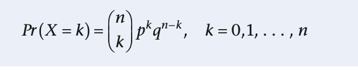

Where:

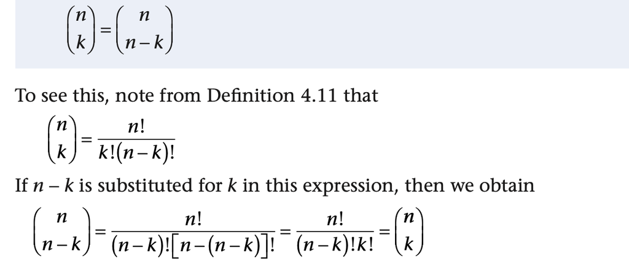

So remember: n = is the number of trials k = is the number of successful events p^k = is the probability of a successful event q^n-k = is the probability of unsuccessful events

Since they are factorial that means we must multiply all numbers preceeding it untill it gets to one.

So using this formula we get:

```r
#z = 5!/0!(5-0)! => 5*4*3*2*1/(5*4*3*2*1 - 1) 1
z =5*4*3*2*1/(5*4*3*2*1 - 1)*1;
z
```

```
## [1] 1.008403
```

```r
#P(X>1) = 1 - (1.00)(0.05)^0(1-0.05)^5-0
np = (1.00)*(0.05)^0*(1-0.05)^5-0
np
```

```
## [1] 0.7737809
```

This gives the non positive probability, then using this we would do this to get positive:

```r
#P(X>1) = 1 - (1.00)(0.05)^0(1-0.05)^5-0
pp = 1-0.7737
pp
```

```
## [1] 0.2263
```

4.34 Suppose 100 women from this population are sampled. What is the probability that 3 or more of them are positive for bacteriuria?

Since this requires the factorial of 100 we will use code for a while to get the factorials:

```r
a = choose(100,0)
p_1= a*(0.05)^0*(1-0.05)^100
b = choose(100,1)
p_2 = b*(0.05)^1*(1-0.05)^99
c = choose(100,2)
p_3 = c*(0.05)^2*(1-0.05)^98

p= p_1 + p_2 + p_3
p
```

```
## [1] 0.118263
```

```r
prob = 1-p
prob
```

```
## [1] 0.881737
```

The probability that 3 or more women are positive is 0.882

## Question Prompt:

One interesting phenomenon of bacteriuria is that there is a “turnover”; that is, if bacteriuria is measured on the same woman at two different points in time, the results are not necessarily the same. Assume that 20% of all women who are bacteriuric at time 0 are again bacteriuric at time 1 (1 year later), whereas only 4.2% of women who were not bacteriuric at time 0 are bacteriuric at time 1. Let X be the random variable representing the number of bacteriuric events over the two time periods for 1 woman and still as- sume that the probability that a woman will be positive for bacteriuria at any one exam is 5%.

4.35 What is the probability distribution of X?

Here we would use the Poison Distribution Mass function, which is bassically a function that gives the probability of observing K events in a time period given the length of the period and the average events per time.

Using this formula we first compute the value for lambda: lambda = n(p) where: n = number of time periods p = probability that the woman will be positive

```r
lambda = (2)*(0.05)
lambda
```

```
## [1] 0.1
```

```r
fact=factorial(0)
fact
```

```
## [1] 1
```

```r
prob0= (10^-0.01)*(0.1)^0/fact
prob0
```

```
## [1] 0.9772372
```

```r
fact=factorial(1)
fact
```

```
## [1] 1
```

```r
prob1= (10^-0.01)*(0.1)^1/fact
prob1
```

```
## [1] 0.09772372
```

```r
fact=factorial(2)
fact
```

```
## [1] 2
```

```r
prob2= (10^-0.01)*(0.1)^2/fact
prob2
```

```
## [1] 0.004886186
```

So the probability distribution for X would be:

```r
data= matrix(c('0.977','0.0977','0.00489'),ncol=3,byrow=TRUE)
colnames(data) = c('(0)','(1)','(2)')
rownames(data) <- c('Outcome')
data=as.table(data)
data
```

```
##         (0)   (1)    (2)
## Outcome 0.977 0.0977 0.00489
```

4.36 What is the mean of X? remember that X is a probability distribution of a random variable, so to calculate the mean and the variable of X we need to calculate the probability distribution of it:

```r
mean_x = (0*0.977)+(1*0.0977)+(2*0.00489)
mean_x
```

```
## [1] 0.10748
```

4.37 What is the variance of X?

Variance formula:

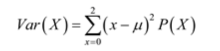

```r
Var_x=(0-0.107)^2*(0.977)+(1-0.106)^2*(0.0977)+(2-0.1)^2*(0.00489)
Var_x
```

```
## [1] 0.1069239
```

## Question Prompt:

Otitis media is a disease that occurs frequently in the first few years of life and is one of the most common reasons for physician visits after the routine checkup. A study was conducted to assess the frequency of otitis media in the general population in the first year of life. Table 4.16 gives the number of infants of 2500 infants who were first seen at birth who remained disease-free by the end of the ith month of life, i = 0, 1, . . . , 12. (Assume no infants have been lost to follow-up.)

4.38 What is the probability that an infant will have one or more episodes of otitis media by the end of the sixth month of life? The first year of life?

Here is the data:

| I | Disease.free.infants.at...the.end.of.month.i |
| --- | --- |
| 0 | 2500 |
| 1 | 2425 |
| 2 | 2375 |
| 3 | 2300 |
| 4 | 2180 |
| 5 | 2000 |
| 6 | 1875 |
| 7 | 1700 |
| 8 | 1500 |
| 9 | 1300 |

[output cut: 3 more lines]

The question asks to find the probability that the infant will have one or more episode at the end of the 6 months. So to do that we look at the table. It is given that 2500 infants started out without the disease, and by the 6th month its 1875 infants without the disease. So the difference is how many episode of ottis we have by the end of six months:

```r
start= 2500
six_month =1875
diff = start-six_month
diff
```

```
## [1] 625
```

Now using that value we can get the probability that an infant will have this disease:

```r
p=diff/start
p
```

```
## [1] 0.25
```

At the end of the year?

Start is still 2500 1 year value is 1200

```r
one_year = 1200
diff = start-one_year
diff
```

```
## [1] 1300
```

```r
p=diff/start
p
```

```
## [1] 0.52
```

4.39 What is the probability that an infant will have one or more episodes of otitis media by the end of the ninth month of life given that no episodes have been observed by the end of the third month of life?

```r
start = 2300
nine_month = 1300
diff = start-nine_month
diff
```

```
## [1] 1000
```

```r
p=diff/start
p
```

```
## [1] 0.4347826
```

4.40 Suppose an “otitis-prone family” is defined as one in which at least three siblings of five develop otitis media in the first 6 months of life.

So 3/5 siblings is the definition of “otitis-prone family”

What proportion of five-sibling families is otitis prone if we assume the disease occurs in- dependently for different siblings in a family?

P(X) >= 3 is our assumption here. So what we know:

start = 2500 disease free

six-month = 1875 disease free

```r
start= 2500
six_month =1875
diff = start-six_month
p=diff/start
p
```

```
## [1] 0.25
```

Now that we have the probability after 6 months, we can use binomial distribution to get the answer:

Getting the factorials:

1. n=5 and k=3 5!/(5-3)!(3)!

```r
x =  5*4*3/6
x
```

```
## [1] 10
```

```r
a=x*(0.25)^3*0.75^2
a
```

```
## [1] 0.08789062
```

2. n=5 and k=4 5!/(5-4)!(4)!

```r
y=5*4*3*2*1/(4*3*2*1)
y
```

```
## [1] 5
```

```r
b= y*(0.25)^4*0.75^1
b
```

```
## [1] 0.01464844
```

3

```r
y=5*4*3*2*1/(5*4*3*2*1)
y
```

```
## [1] 1
```

```r
c= y*(0.25)^4*0.75^1
c
```

```
## [1] 0.002929688
```

```r
prob = a+b+c
prob
```

```
## [1] 0.1054688
```

So the probability is 0.105.

4.41 What is the expected number of otitis-prone families of 100 five-sibling families?

So remember p = 0.25 from the 6 month period of infants who have the disease and the 0.75 for those that don’t because 1-0.25 = 0.75.

And we know that the probability of ottis prone family for siblings is 0.105. We can use that to cacluate the 100 families by using the expectation of the binomial random variable

```r
n = 100
p = 0.105
E = n*p
E
```

```
## [1] 10.5
```

So the expectation is around 10 or 11 if we round up.

# Chapter 5:

## Question Prompt:

Suppose we observe 84 alcoholics with cirrhosis of the liver, of whom 29 have hepatomas—that is, liver-cell carci- noma. Suppose we know, based on a large sample, that the risk of hepatoma among alcoholics without cirrhosis of the liver is 24%.

5.50 What is the probability that we observe exactly 29 alcoholics with cirrhosis of the liver who have hepatomas if the true rate of hepatoma among alcoholics (with or without cirrhosis of the liver) is .24?

What we know:

84 alcoholics

29 out of 84 have hepatomas

n = 84 - number of alcoholics x = 29 - alcoholics given that have hepatoma That means 1-0.24= 0.76 don’t have it

```r
a = choose(84,29)
prob = a*(0.24)^29*(0.76)^55
prob
```

```
## [1] 0.008730478
```

5.51 What is the probability of observing at least 29 hepa- tomas among the 84 alcoholics with cirrhosis of the liver under the assumptions in Problem 5.50?

Here the equation is half done, bassically its:

P(x) = ( 84 )(0.24)<sup>x(0.76)</sup>84-x ( x ) Bassically we don’t have the x value, so we use 1-pbinomial(28,84,0.24) where 28 is the unknown, 84 is n, and 0.24 is the probability

```r
a= 1-pbinom(28,84,0.24)
a
```

```
## [1] 0.01935102
```

5.52 What is the smallest number of hepatomas that would have to be observed among the alcoholics with cirrhosis of the liver for the hepatoma experience in this group to differ from the hepatoma experience among alcoholics without cirrhosis of the liver? (Hint: Use a 5% probability of getting a result at least as extreme to denote differences between the hepatoma experiences of the two groups.)

First we calculate the number of hepatomas in the alcoholic population with cirrhosis of the liver at 5%. P(X>=x) = 0.05 P(X>=x) = 1-0.05 = 0.95

So here we will calculate the mean and the standard deviation:

```r
n = 84
p = 0.24
mean = n*p
std = sqrt((n*p)*(1-p))
std
```

```
## [1] 3.914282
```

Now we can use the normal approximation of the binomial distribution to calculate hepatoma in alcoholics without cirrhosis of the liver at 5%. P(X-mean/std =< x-20.16/3.9143) = 0.95

here we use the z score of 95% to get 1.96 x-20.16/3.9143 = 1.96 (3.9143)*(1.96)= x-20.16 x = (3.9143)*(1.96)+20.16

```r
x = (3.9143)*(1.96)+20.16
x
```

```
## [1] 27.83203
```

Obesity is an important determinant of cardiovascular dis- ease because it directly affects several established cardio- vascular risk factors, including hypertension and diabetes. It is estimated that the average weight for an 18-year-old woman is 123 lbs. and increases to 142 lbs. at 50 years of age. Also, let us assume that the average SBP for a 50-year-old woman is 125 mm Hg, with a standard deviation of 15 mm Hg, and that SBP is normally distributed.

5.71 What proportion of 50-year-old women is hyperten- sive, if hypertension is defined as SBP ≥ 140 mm Hg?

random variable X is here will be the systolic blood pressure of a 50 year old woman.

mean of systolic blood pressure: 125 mmHg std: 15 mmhg

P(X>=140)=1-P(X=<140) P(X>=140)= 1- (X-mean/std) P(X>=140)= 1-((140-125)/(15))

((140-125)/(15)) = 1

normal distribution of 1 (from table) = 0.8413

```r
y = 0.8413
X_greater = 1-y
X_greater
```

```
## [1] 0.1587
```

The propotion of 50 year old women is hypertensive is 0.1587.

From previous clinical trials, it is estimated that for every 10 lbs. of weight loss there is, on average, a corresponding reduction in mean SBP of 3 mm Hg.

5.72 Suppose an average woman did not gain any weight from age 18 to 50. What average SBP for 50-year-old women would be expected under these assumptions?

So for every 10 lbs weight loss = reduction of 3 mmHg in Systolic Blood pressure

mean for 50 year old women = 125 mmhg std for 50 year old woman = 15 mmhg So weight not gained from 18-50:

```r
x = (142-123)/10
x
```

```
## [1] 1.9
```

```r
Est= 125-(x)*3
Est
```

```
## [1] 119.3
```

The answer is 119.3 mmhg

5.73 If the standard deviation of SBP under the assumption in Problem 5.72 remained the same (15 mm Hg), and the distribution of SBP remained normal, then what would be the expected proportion of hypertensive women under the assumption in Problem 5.72?

So using the answer from previous question: P(systolic >= 140) = P(Systolic Blood Pressure - Estimated Systolic/Std >= 140 -119.3/15) this becomes: P(z>=1.38) 1-P(z>=1.38) Z score of 1.38 is 0.9162

```r
expected = 1- 0.9162
expected
```

```
## [1] 0.0838
```

Expected proportion is 0.0838.

5.74 What percentage of hypertension at age 50 is attributable to the weight gain from age 18 to 50?

P(123 =< Systolic Blood Pressure =< 142) = P(123 - 125/Std(systolic) =< systolic - 125/Std(systolic) =< 142 - Est(systolic)/Std(systolic))

P(125-125/15 =< z =< 142-125/15)

P(-0.1333 =< z =< 1.133)

which becomes:

```r
P= (0.872 - 0.447)*100
P
```

```
## [1] 42.5
```